# Data Appendix

Madeleine Hickman, Christian Madrigal, Nukhbah Majid, Annabel Shein

November 18, 2019

# Due November 15 11:55pm on Moodle

note- do not change any part of the above after the `output` line! This time you can add to the R Markdown document you started with your project proposal to bring in the data, and to add a section for your data exploration. **Be sure to have purpose, data, population, response variables, explanatory variables sections (which are from the initial proposal) reflect the comments that Miles made on your initial proposal.**

```r
# you may need to add more packages here
library(dplyr)
library(ggplot2)
library(readr)
library(fivethirtyeight)
```

```r
bechdelSample <- read_csv("bechdelSample.csv")
```

# Bechdel Test

**Group members:** Madeleine Hickman, Christian Madrigal, Nukhbah Majid, Annabel Shein

## Purpose

The Bechdel test is a measure of representation of women in fiction, and is used a lot for movies. A movie passes the Bechdel test if two women talk to each other about something other than a man, and sometimes the requirement that the women are named is added as well. We want to see trends in gender representation in movies across genre and decade and if there is a relationship in how well the movies do financially and if they pass the Bechdel test.

Some questions we have: - Does the number of movies passing the Bechdel test change over time? - Which genre of movie has the most movies that pass the Bechdel test? - Does the gender of the director affect whether or not the movie passes the Bechdel test? - Is there a relationship between the movie passing the Bechdel test and how much money the movie makes?

## The Data

The data we plan to use is from the Fivethirtyeight library on R, the dataset is called Bechdel. This dataset has 1794 cases, which are movies form 1970 to 2013. We plan to exclude all movies released prior to 1990 and use a random sample of 200 movies from this dataset. The Bechdel dataset is made up of movies that Fivethirtyeight analyzed, using data they collected form other sources. We are assuming that these movies were randomly drawn from all movies that were released from that time period for the sake of our project, but we know that this assumption probably won’t stand.

### Population

The cases in our dataset are 200 movies, randomly sampled from our original dataset of movies released between 1990 and 2013. The population we are generalizing to is popular movies released between 1990 and 2013. We roughly estimate the population size to be 13,800 movies.

### Response Variables

Passing the Bechdel test (binary) (PASS/FAIL) Domestic gross (USD, adjusted for inflation around dollar value in 2013) International gross (USD, adjusted for inflation around dollar value in 2013)

### Explanatory Variables

Passing the Bechdel test (binary) (PASS/FAIL) Decade (ex: 90s, 2000s) Director’s gender (male/female) Movie genre (Comedy, Action, Drama, Other) Budget (USD, adjusted for inflation around dollar value in 2013) Test (notalk, men, ok, dubious, nowomen)

## Data Exploration

```r
library(dplyr)
library(ggplot2)
library(oilabs)
```

```r
bechdelSample %>%
  mutate(domgross_2013_mil = domgross_2013/1000000, intgross_2013_mil = intgross_2013/1000000, budget_2013_mil = budget_2013/1000000)
```

| year | imdb | title | test | clean_test | binary | budget | domgross | intgross | code | budget_2013 | domgross_2013 | intgross_2013 | period_code | decade_code | domgross_2013_mil | intgross_2013_mil | budget_2013_mil |
| --- | --- | --- | --- | --- | --- | --- | --- | --- | --- | --- | --- | --- | --- | --- | --- | --- | --- |
| 2009 | tt0409459 | Watchmen | men-disagree | men | FAIL | 138000000 | 107509799 | 184068357 | 2009FAIL | 149830960 | 116726786 | 199848831 | 2 | 2 | 116.726786 | 199.848831 | 149.830960 |
| 1999 | tt0165643 | Black and White | ok | ok | PASS | 10000000 | 5241315 | 5241315 | 1999PASS | 13984620 | 7329780 | 7329780 | 4 | 3 | 7.329780 | 7.329780 | 13.984620 |
| 2004 | tt0375063 | Sideways | ok | ok | PASS | 17000000 | 71502303 | 109874155 | 2004PASS | 20964279 | 88176131 | 135496025 | 3 | 2 | 88.176131 | 135.496025 | 20.964279 |
| 2005 | tt0398712 | Assault on Precinct 13 | ok | ok | PASS | 30000000 | 20040895 | 36040895 | 2005PASS | 35790994 | 23909452 | 42997982 | 2 | 2 | 23.909452 | 42.997982 | 35.790994 |
| 2013 | tt1814621 | Admission | ok | ok | PASS | 13000000 | 18007317 | 18007317 | 2013PASS | 13000000 | 18007317 | 18007317 | 1 | 1 | 18.007317 | 18.007317 | 13.000000 |
| 2002 | tt0258068 | The Quiet American | men | men | FAIL | 20000000 | 12987647 | 26348203 | 2002FAIL | 25903584 | 16821330 | 34125645 | 3 | 2 | 16.821330 | 34.125645 | 25.903584 |
| 2003 | tt0287978 | Daredevil | nowomen-disagree | nowomen | FAIL | 80000000 | 102543518 | 182782518 | 2003FAIL | 101286957 | 129829011 | 231418562 | 3 | 2 | 129.829011 | 231.418562 | 101.286957 |
| 1991 | tt0101452 | Bill & Ted’s Bogus Journey | notalk | notalk | FAIL | 20000000 | 37537675 | 37537675 | 1991FAIL | 34216807 | 64220970 | 64220970 | 5 | 3 | 64.220970 | 64.220970 | 34.216807 |
| 2011 | tt1253864 | Immortals | men | men | FAIL | 75000000 | 83504017 | 211562435 | 2011FAIL | 77676809 | 86484341 | 219113265 | 1 | 1 | 86.484341 | 219.113265 | 77.676809 |
| 2007 | tt0367959 | Hannibal Rising | notalk | notalk | FAIL | 50000000 | 27669725 | 80583311 | 2007FAIL | 56177174 | 31088139 | 90538854 | 2 | 2 | 31.088139 | 90.538854 | 56.177174 |
| 2010 | tt1386588 | The Other Guys | nowomen-disagree | nowomen | FAIL | 100000000 | 119219978 | 170936470 | 2010FAIL | 106823184 | 127354577 | 182599780 | 1 | 1 | 127.354577 | 182.599780 | 106.823184 |
| 2013 | tt2002718 | Machete Kills | ok | ok | PASS | 2000000 | 8008161 | 9408161 | 2013PASS | 2000000 | 8008161 | 9408161 | 1 | 1 | 8.008161 | 9.408161 | 2.000000 |
| 2006 | tt0429589 | The Ant Bully | men | men | FAIL | 45000000 | 28142535 | 49610898 | 2006FAIL | 52010836 | 32527039 | 57340095 | 2 | 2 | 32.527039 | 57.340095 | 52.010836 |
| 2007 | tt0449088 | Pirates of the Caribbean: At World’s End | ok | ok | PASS | 300000000 | 309420425 | 960996492 | 2007PASS | 337063045 | 347647302 | 1079721346 | 2 | 2 | 347.647302 | 1079.721346 | 337.063045 |
| 2011 | tt1192628 | Rango | notalk-disagree | notalk | FAIL | 135000000 | 123257581 | 245504574 | 2011FAIL | 139818256 | 127656741 | 254266825 | 1 | 1 | 127.656741 | 254.266825 | 139.818256 |
| 2006 | tt0398913 | DOA: Dead or Alive | ok | ok | PASS | 30000000 | 480314 | 7756224 | 2006PASS | 34673890 | 555145 | 8964615 | 2 | 2 | 0.555145 | 8.964615 | 34.673890 |
| 1999 | tt0122933 | Analyze This | notalk | notalk | FAIL | 30000000 | 106885658 | 176885658 | 1999FAIL | 41953861 | 149475534 | 247367876 | 4 | 3 | 149.475534 | 247.367876 | 41.953861 |
| 2009 | tt1080016 | Ice Age: Dawn of the Dinosaurs | notalk | notalk | FAIL | 90000000 | 196573705 | 886968695 | 2009FAIL | 97715844 | 213426283 | 963009937 | 2 | 2 | 213.426283 | 963.009937 | 97.715844 |
| 2013 | tt1979320 | Rush | notalk | notalk | FAIL | 38000000 | 26947624 | 43047624 | 2013FAIL | 38000000 | 26947624 | 43047624 | 1 | 1 | 26.947624 | 43.047624 | 38.000000 |
| 2009 | tt0452694 | The Time Traveler’s Wife | dubious | dubious | FAIL | 39000000 | 63414846 | 98666635 | 2009FAIL | 42343532 | 68851502 | 107125483 | 2 | 2 | 68.851502 | 107.125483 | 42.343532 |
| 2011 | tt1422136 | A Lonely Place to Die | ok | ok | PASS | 4000000 | NA | 442550 | 2011PASS | 4142763 | NA | 458345 | 1 | 1 | NA | 0.458345 | 4.142763 |
| 2005 | tt0382628 | Dark Water | ok | ok | PASS | 60000000 | 25473093 | 49473093 | 2005PASS | 71581988 | 30390244 | 59023039 | 2 | 2 | 30.390244 | 59.023039 | 71.581988 |
| 2008 | tt0887883 | Burn After Reading | notalk | notalk | FAIL | 37000000 | 60355347 | 163415735 | 2008FAIL | 40043484 | 65319955 | 176857711 | 2 | 2 | 65.319955 | 176.857711 | 40.043484 |
| 2007 | tt0481369 | The Number 23 | notalk | notalk | FAIL | 32000000 | 35193167 | 77593167 | 2007FAIL | 35953391 | 39541053 | 87179297 | 2 | 2 | 39.541053 | 87.179297 | 35.953391 |
| 2006 | tt0493430 | Jackass Number Two | notalk | notalk | FAIL | 11000000 | 72778712 | 85278712 | 2006FAIL | 12713760 | 84117369 | 98564824 | 2 | 2 | 84.117369 | 98.564824 | 12.713760 |
| 2010 | tt1228987 | Let Me In | notalk-disagree | notalk | FAIL | 20000000 | 12134935 | 28270399 | 2010FAIL | 21364637 | 12962924 | 30199340 | 1 | 1 | 12.962924 | 30.199340 | 21.364637 |
| 1998 | tt0120780 | Out of Sight | men | men | FAIL | 48000000 | 37562568 | 77562568 | 1998FAIL | 68598351 | 53681880 | 110847172 | 4 | 3 | 53.681880 | 110.847172 | 68.598351 |
| 2013 | tt1980209 | Pain & Gain | notalk | notalk | FAIL | 26000000 | 49875291 | 81275291 | 2013FAIL | 26000000 | 49875291 | 81275291 | 1 | 1 | 49.875291 | 81.275291 | 26.000000 |
| 2007 | tt0473308 | Waitress | ok | ok | PASS | 1500000 | 19097550 | 22217183 | 2007PASS | 1685315 | 21456928 | 24961971 | 2 | 2 | 21.456928 | 24.961971 | 1.685315 |
| 2002 | tt0293662 | The Transporter | nowomen | nowomen | FAIL | 21000000 | 25296447 | 43928932 | 2002FAIL | 27198764 | 32763432 | 56895840 | 3 | 2 | 32.763432 | 56.895840 | 27.198764 |

[output cut: 170 more lines]

# Variable 1: Binary

### summary statistics

This can be either an expanatory or a response variable, and it is catergorical (PASS/FAIL).

```r
bechdelSample %>%
  group_by(binary) %>%
  summarize(sample_size = n())
```

| binary | sample_size |
| --- | --- |
| FAIL | 122 |
| PASS | 78 |

### data visualizations

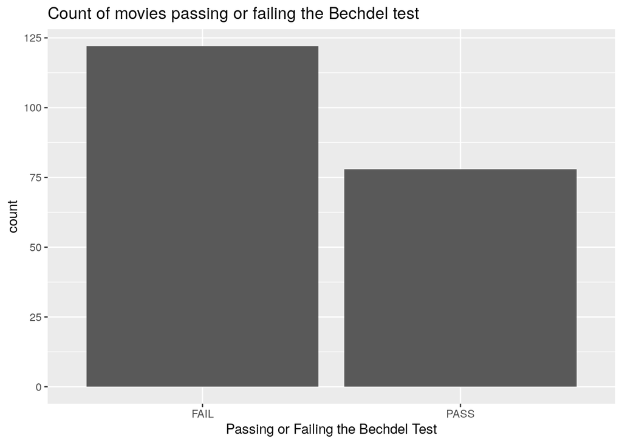

```r
ggplot(data = bechdelSample,  aes(x = binary)) +
  geom_bar()+labs(x="Passing or Failing the Bechdel Test", title="Count of movies passing or failing the Bechdel test")
```

Binary is a catergorical variable. The sample sizes of the pass/fail groups are shown above, as well as a bar plot comparing the number of movies passing and failing the Bechdel test. The summary statistics table and the data visualization both show that within this sample, more movies fail the Bechdel test than pass, 122 and 78, respectively. There are no missing samples.

# Variable 2: Budget

### summary statistics

```r
bechdelSample %>%
  summarize(min_budget = min(budget_2013),
            Mdn_budget = median(budget_2013),
            M_budget = mean(budget_2013),
            q_50_budget = quantile(budget_2013, 0.5),
            max_budget = max(budget_2013),
            sample_size = n())
```

| min_budget | Mdn_budget | M_budget | q_50_budget | max_budget | sample_size |
| --- | --- | --- | --- | --- | --- |
| 371291 | 38452161 | 58816959 | 38452161 | 337063045 | 200 |

### data visualizations

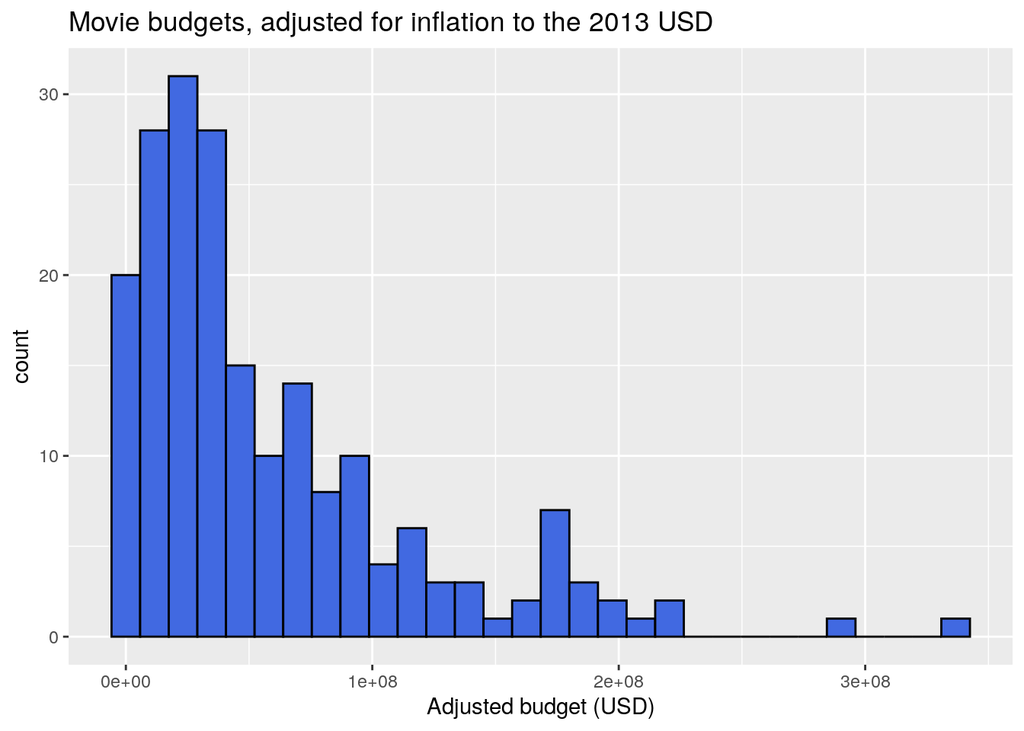

```r
ggplot(data = bechdelSample, aes(x = budget_2013))+
  geom_histogram(fill = "royalblue", color = "black") +
  labs(x = "Adjusted budget (USD)",
       title = "Movie budgets, adjusted for inflation to the 2013 USD")
```

This variable, buget_2013, looks at the budgets for each film in our dataset. The values are adjusted for inflation, according to the value of the USD in 2013.

As all of these movies had to be well-known in order to be chosen for this test, the budgets are all relatively high, with the minimum value sitting at 371291 USD. Our summary statistics and our data visualization for this variable show us that the budgets for these movies are right-skewed, meaning there are a couple movies with extremely large budgets. Because our data is skewed in this way, the mean is pulled upwards by these high budgets, coming in at 58816959 USD, making it much larger than our median budget, which is 38452161 USD.

## Variable 3: Domestic Gross Income

### summary statistics

```r
bechdelSample %>%
  summarize(M_dom = mean(domgross_2013, na.rm=TRUE),
            Mdn_dom = median(domgross_2013, na.rm=TRUE),
            q_1 = quantile(domgross_2013, 0.25,na.rm=TRUE),
            q_3 = quantile(domgross_2013, 0.75, na.rm=TRUE),
            sample_size = n())
```

| M_dom | Mdn_dom | q_1 | q_3 | sample_size |
| --- | --- | --- | --- | --- |
| 82642634 | 51470650 | 20254483 | 104769002 | 200 |

### data visualizations

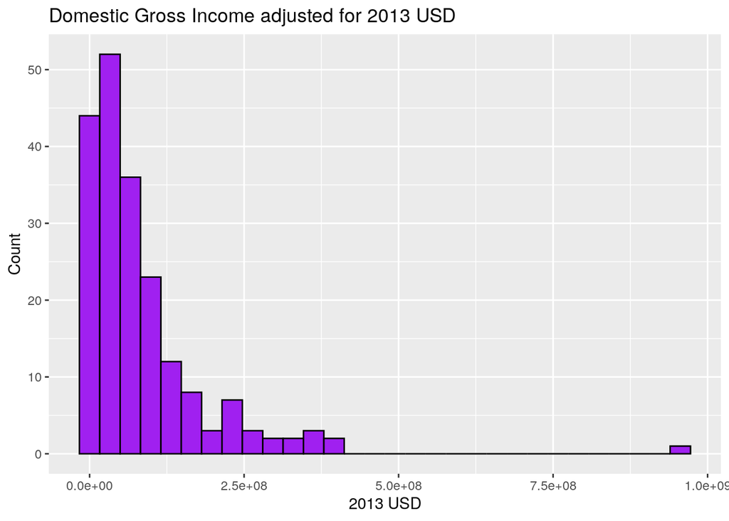

```r
ggplot(data = bechdelSample, aes(x = domgross_2013))+
  geom_histogram(fill="purple", color = "black") + labs(x="2013 USD", y="Count", title="Domestic Gross Income adjusted for 2013 USD")
```

The domestic gross income, adjusted for 2013 USD, is very skewed to the right. The sample of 200 movies clearly demonstrates that there were over 50 cases that made over 20,000,000 USD in domestic gross income. There are also several cases that are outliers in comparison to the other cases and they are the ones that are visually represented on the right of the histogram. There are two cases, that did not have information on the domestic gross income, therefore this visualization is specifically showing data on 198 cases.

## Variable 4: International Gross Income

### summary statistics

```r
bechdelSample %>%
  summarize(M_int = mean(intgross_2013, na.rm=TRUE),
            Mdn_int = median(intgross_2013, na.rm=TRUE),
            q_1 = quantile(intgross_2013, 0.25,na.rm=TRUE),
            q_3 = quantile(intgross_2013, 0.75, na.rm=TRUE),
            sample_size = n())
```

| M_int | Mdn_int | q_1 | q_3 | sample_size |
| --- | --- | --- | --- | --- |
| 192525922 | 97402049 | 38622501 | 219342549 | 200 |

### Data Visualizations

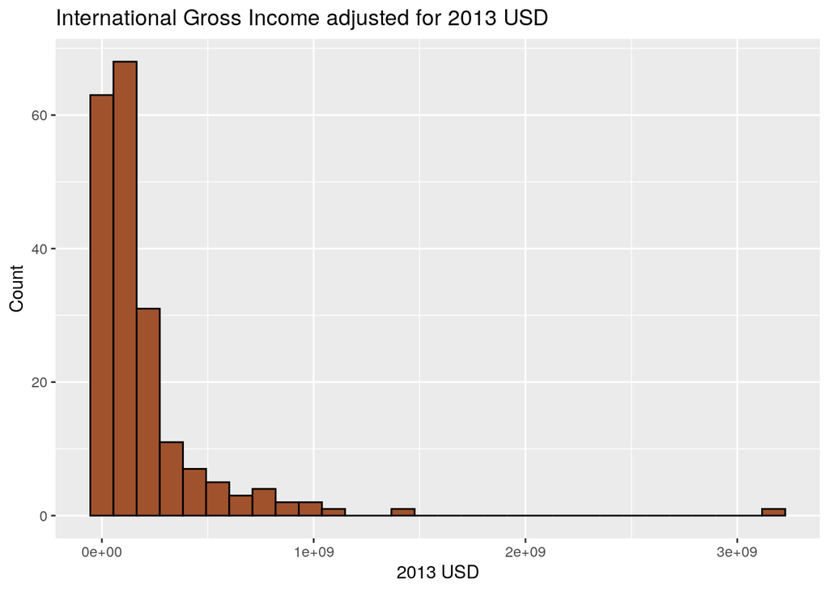

```r
ggplot(data = bechdelSample, aes(x = intgross_2013))+
  geom_histogram(fill="sienna", color = "black")+ labs(x="2013 USD", y="Count", title="International Gross Income adjusted for 2013 USD")
```

# Variable 5: Test

```r
testBechdel <- bechdelSample %>%
  group_by(year) %>%
  mutate(total = n()) %>%
  group_by(year, binary) %>%
  mutate(passNum = ifelse(binary == "PASS", n(), total-n() ) )
```

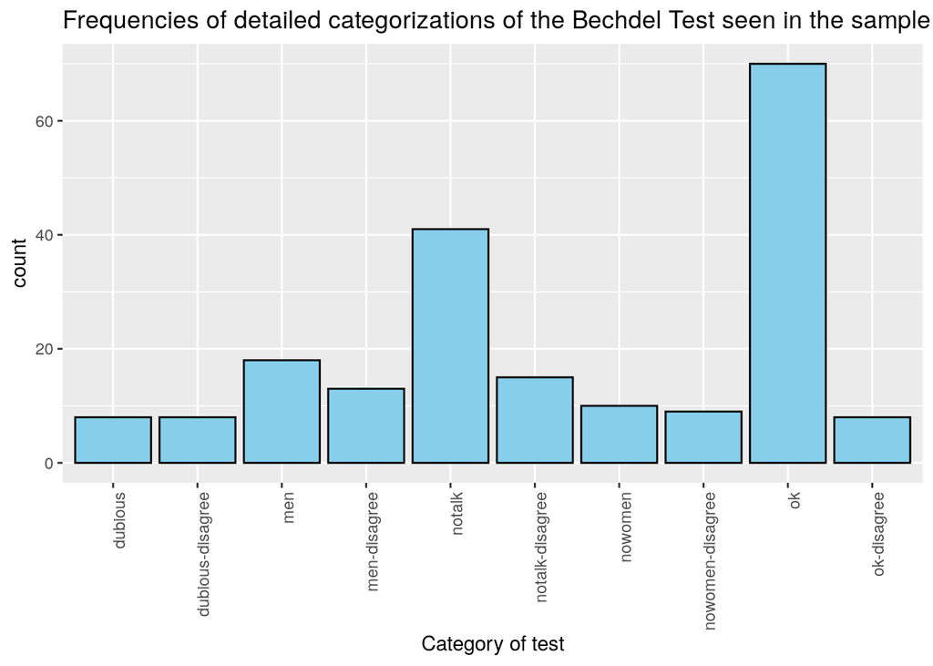

```r
ggplot(testBechdel, aes(x= test))+
  geom_bar(fill = "skyblue", color = "black") +
  theme(axis.text.x = element_text(angle = 90, hjust = 1)) +
  labs(title = "Frequencies of detailed categorizations of the Bechdel Test seen in the sample", x = "Category of test")
```

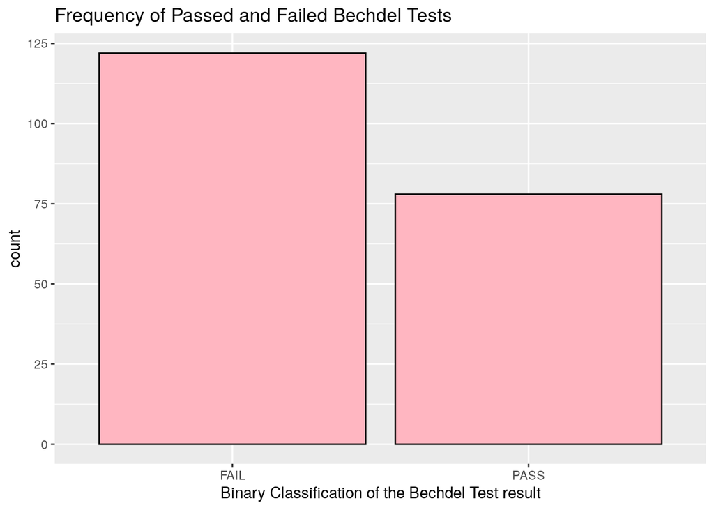

```r
ggplot(testBechdel, aes(x= binary))+
  geom_bar(fill = "lightpink", color = "black") +
  labs(title = "Frequency of Passed and Failed Bechdel Tests", x = "Binary Classification of the Bechdel Test result")
```

The data visualizations above explore the `test` variable and the levels associated with the `test` categorical variable. The categories in the first graphic are explained below:

- `ok` = passes test
- `dubious` = inconclusive result for reasons not explained by the dataset description.
- `men` = women only talk about men
- `notalk` = women don’t talk to each other
- `nowomen` = fewer than two women

The first graphic gives a rough idea that maybe more movies passed the bechdel test than the movies that failed the test. This misconception is cleared up by the second data graphic since the `binary` since it condenses the categories in `test` to either pass or fail labels for each of the movies. Hence, we see that more movies failed the bechdel test than pass it.

## Variables 6-10

The “bechdelSample” data set we are using doesn’t contain very many variables, so we are adding 5 new variables, three of which are categorical and two of which are quantitative.

We are hoping to explore the question of representation of women in Hollywood through examining different features of popular films released, and we are hoping these new variables will teach us things about what might influence the way women are portrayed in film.

Quantitative variables we are adding:

- IMDB_score: This variable will be a quantitative variable with values ranging from 0.0 to 10.0, with the value representing the IMDB user rating given to the film. We can look at the average and median values for this variable and also max and min values.
- opening_weekend: This variable would contain the numerical value for the opening weekend sales for each movie. We could look at the 5-number summary for this variable to look at generally how successful the movies were in their opening weekends. One limitation of this data is that it will not be adjusted for inflation, so it will be difficult for us to compare this variable with the other quantitative variables that are measured in USD, or to make generalizations about this variable in relation to the other conclusions we will be drawing about our data.